# Carnac Menhirs Player Investment and Performance Analytics

Salary, Crowd and Goal-Shooting Decision Support

Md Soad Solaiman

7 June 2025

# 1. Executive Summary

Carnac Menhirs is a proposed team in an upcoming French professional netball league. The management committee and treasurer are evaluating player remuneration under a venue income-sharing arrangement. Higher crowd contributes directly to team income under this arrangement. This report examines salary patterns across positions. It then focuses on Goal Shooters, where salary, crowd and shooting accuracy are analysed together.

All dollar figures are Australian dollars.

The standard salary budget is approximately AUD 120,000 per player. Up to AUD 500,000 may be considered for an exceptional recruit, if supported by strong evidence. The analysis cleans 14,000 player-season records down to 13,996 analysis-ready records. A reproducible sample of 1,350 Goal Shooters is drawn for detailed modelling. Box-Cox transformations and linear regression are used to model shooting accuracy from salary. Predictions are reported at the required 97% level.

Age and salary distributions are similar across positions. Goal Attack and Goal Shooter carry marginally higher median salaries. Salary shows no clear relationship with experience. Goal Shooter salary has a positive association with shooting accuracy in the sample studied. The fitted salary coefficient is statistically significant, with a strong in-sample fit. At AUD 330,000, however, the model predicts 100.2% accuracy. Because accuracy cannot exceed 100%, this identifies a limitation of the model near its upper boundary. It does not mean salary has no predictive value.

# 2. Business Context

Carnac Menhirs allocates salary across seven positions: Goal Shooter, Goal Attack, Wing Attack, Centre, Wing Defence, Goal Defence and Goal Keeper. Only Goal Shooter and Goal Attack score goals. Goal Shooter is the more direct scoring position. Management believes stronger players may lift scoring, spectator demand and commercial return.

The data can test associations between salary, crowd and performance. It cannot estimate income per game or full financial return. No revenue, venue-sharing percentage or cost data is available.

# 3. Investment Decision

The committee and treasurer must decide how much weight this analysis should carry in recruitment and salary decisions. The standard budget is approximately AUD 120,000 per player. An exceptional recruit may receive up to AUD 500,000. Any prediction used in this decision must include a 97% interval.

# 4. Analytical Questions

- Compare player age and salary distributions across positions.
- Test salary against experience and average crowd.
- Analyse Goal Shooter salary, crowd and shooting accuracy together.
- Transform non-linear relationships and fit a linear model.
- Check model assumptions and produce salary-based predictions with 97% intervals.
- Separate evidence useful for recruitment from evidence too weak for a financial commitment.

# 5. Dataset

The source is a de-identified player-season dataset. It contains 14,000 rows and nine variables: player identifier, date of birth, height, playing experience, salary, position, goals, misses and average crowd. Salary is expressed in purchasing-power-adjusted Australian dollars. A player may appear in multiple seasons under different identifiers.

Source player records before cleaning

| U.N.I. | DATE of BIRTH | Height | PE | $alary | POS. | GOALS | MISSUS | Av Att |
| --- | --- | --- | --- | --- | --- | --- | --- | --- |
| B71067 | 1991-06-14 | 1.72 | 2 | $50,153.05 | WA | 0 | 0 | 13827.1 |
| B42191 | 1990-11-22 | 1.83 | 3 | $181,856.34 | GK | 0 | 0 | 3651.5 |
| B31532 | 1994-08-26 | 1.87 | 4 | $208,061.15 | GK | 0 | 0 | 2573.6 |

# 6. Data Quality and Preparation

## 6.1 Cleaning summary

The cleaning process uses a fixed random seed, so the row order is reproducible. Each record is checked for validity before analysis.

Player identifiers are unique, with 0 duplicates found. The review removes 4 invalid records: one future birth year, 1 non-numeric salary entry, one salary outlier of AUD 1,000,000, and one goal total of 10,000. One negative height value is corrected to its absolute value. This leaves 13996 analysis-ready records.

Negative-value checks after cleaning

| field | Negative records |
| --- | --- |
| Experience | 0 |
| Salary | 0 |
| Goals | 0 |
| Misses | 0 |
| Average crowd | 0 |

No remaining field contains negative values. The lowest and highest values for height, experience, misses and crowd were also checked directly. No further errors were found.

Player age is calculated as at 4 July 2025. Date of birth is then dropped, and salary is rescaled to AUD thousands for readability.

Analysis-ready player records (sample)

| prn | uni | Height | experience | salary | position | goals | misses | avg_crowd | age_y |
| --- | --- | --- | --- | --- | --- | --- | --- | --- | --- |
| 1 | B47174 | 1.87 | 1 | 147.41398 | C | 0 | 0 | 3998.1 | 23 |
| 2 | B99991 | 1.84 | 14 | 63.61085 | GK | 0 | 0 | 13707.2 | 35 |
| 3 | B60028 | 1.80 | 7 | 61.07081 | GS | 362 | 234 | 2446.2 | 31 |
| 4 | B58954 | 1.82 | 0 | 142.70164 | C | 0 | 0 | 14376.1 | 23 |
| 5 | B78980 | 1.82 | 3 | 111.13922 | GD | 0 | 0 | 4161.5 | 25 |

# 7. Player Profile by Position

## 7.1 Height and crowd

Player height is close to symmetric, with a skewness of -0.0029. It centres around 1.80 metres.

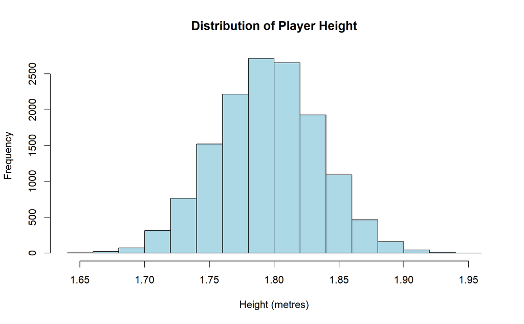

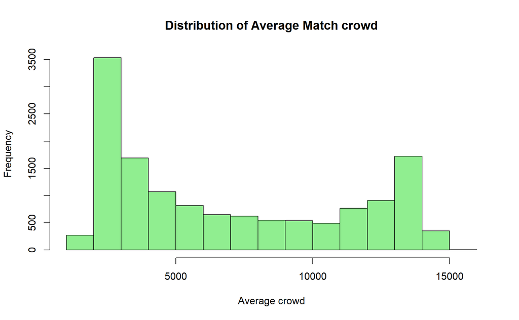

## 7.2 Age and salary by position

Age is fairly uniform across positions. Median age sits around 28 years, with similar spread throughout.

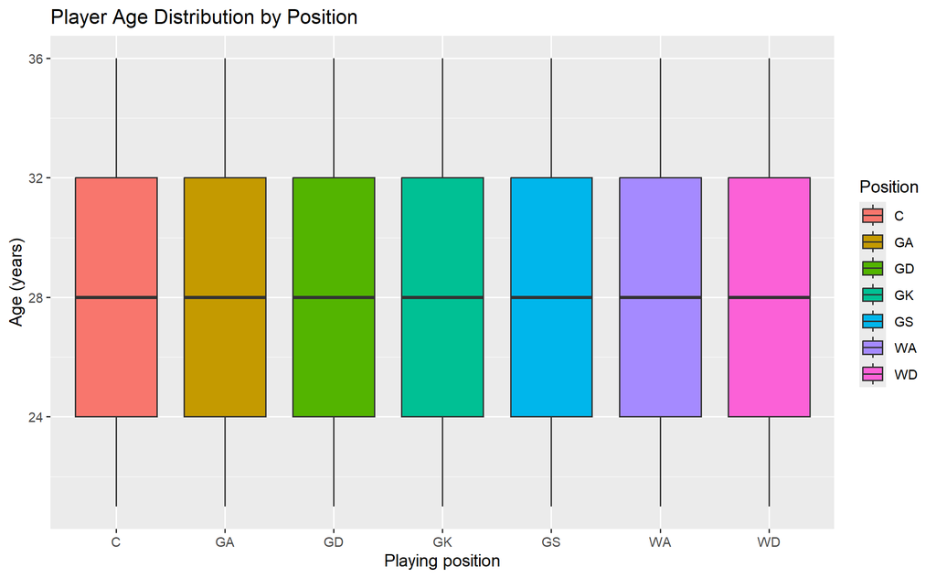

Salary is also broadly similar across positions. Most medians sit just above AUD 100,000. Goal Attack and Goal Shooter run marginally higher.

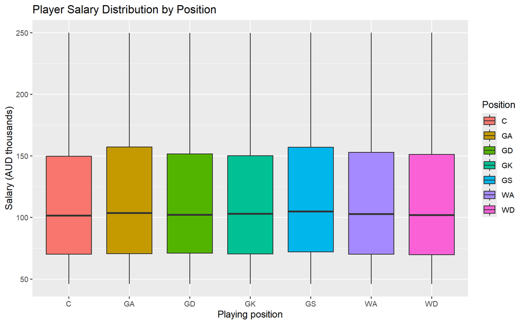

## 7.3 Salary against experience and crowd

Salary shows no clear relationship with experience, in any position.

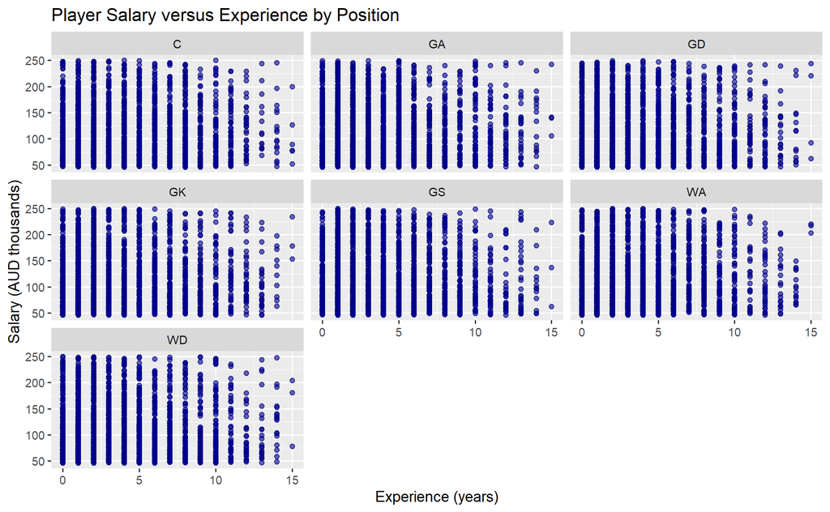

Salary and crowd show no clear pattern for most positions. Goal Shooter is the exception. It shows a clear positive trend.

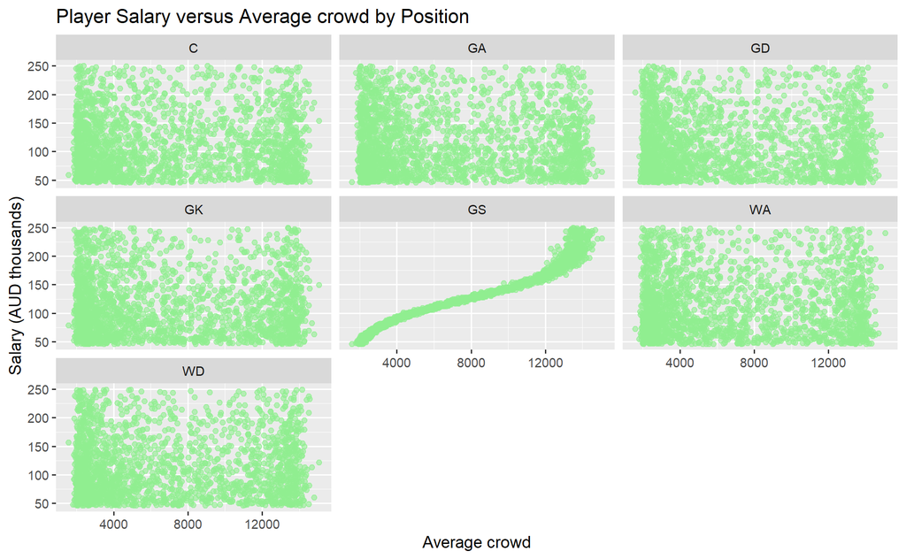

# 8. Goal Shooter Analysis

Goal Shooter is isolated for closer study, since it is the position most directly tied to scoring. Shooting accuracy is defined as:

$$\text{accuracy} = \frac{\text{goals}}{\text{goals} + \text{misses}}$$

A reproducible sample of 1350 Goal Shooters is drawn for modelling.

Goal Shooter modelling sample (sample rows)

| prn | uni | Height | experience | salary | accuracy | goals | avg_crowd | age_y |
| --- | --- | --- | --- | --- | --- | --- | --- | --- |
| 5129 | B60927 | 1.83 | 1 | 97.46084 | 0.7166948 | 425 | 4403.7 | 21 |
| 147 | B39614 | 1.83 | 0 | 116.42843 | 0.7574257 | 459 | 6720.8 | 21 |
| 8689 | B13382 | 1.73 | 1 | 46.82878 | 0.5992908 | 338 | 2048.5 | 24 |
| 5600 | B63044 | 1.86 | 1 | 86.69913 | 0.7083812 | 617 | 3568.7 | 25 |
| 5392 | B20712 | 1.80 | 0 | 175.79877 | 0.8460543 | 654 | 12640.4 | 22 |

## 8.1 Salary and Crowd

Crowd rise with Goal Shooter salary. The trend is positive, but curved. A straight line does not fully capture its shape.

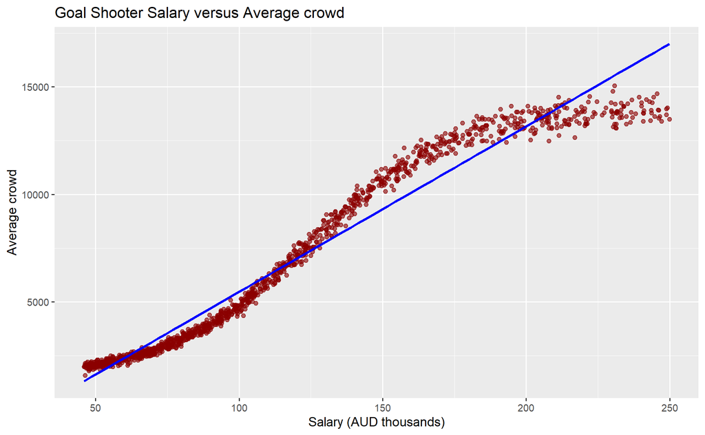

# 9. Transformations

## 9.1 Crowd

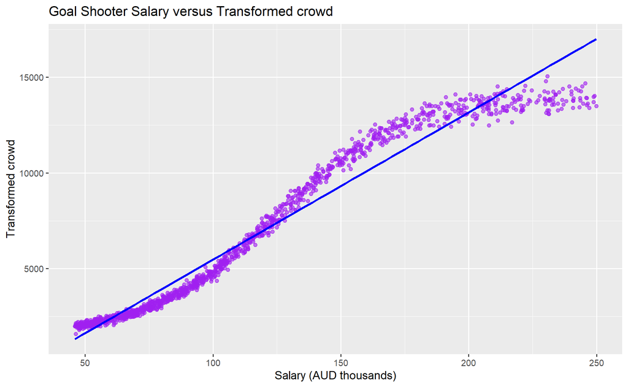

## 9.2 Shooting accuracy

Salary shows a positive association with shooting accuracy. The raw relationship is non-linear.

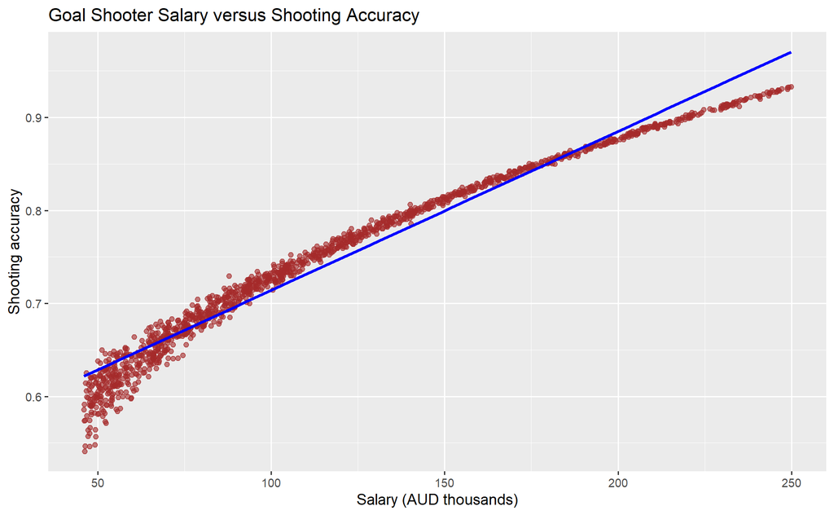

A Box-Cox lambda of 3.85 is selected for accuracy. After transformation, the salary relationship becomes substantially more linear.

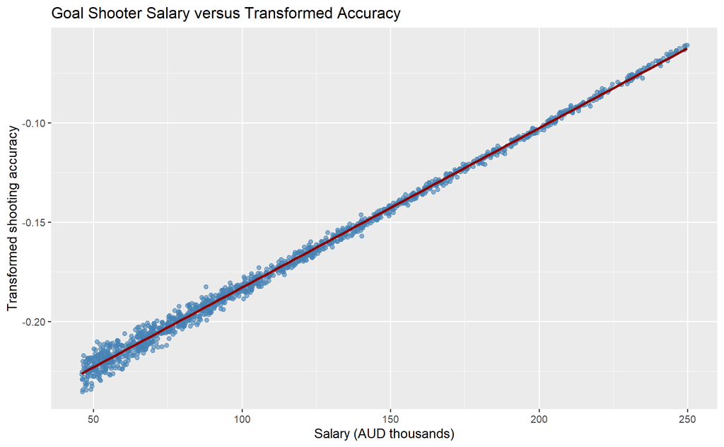

# 10. Linear Model

The model relates transformed accuracy to salary:

$$y_i = \beta_0 + \beta_1 x_i + \varepsilon_i,
\qquad
\varepsilon_i \sim N(0, \sigma^2)$$

where $y_i$ is transformed accuracy and $x_i$ is salary in AUD thousands.

Fitted model coefficients

| term | estimate | std.error | statistic | p.value |
| --- | --- | --- | --- | --- |
| (Intercept) | -0.2632000 | 1.79e-04 | -1471.0 | 0 |
| salary | 0.0008032 | 1.40e-06 | 580.9 | 0 |

The fitted equation is:

$$\hat{y}_i = -0.2632 + 8.032\times 10^{-4} x_i$$

The salary coefficient is significant at $p < 2\times10^{-16}$. The model explains $R^2 = 0.996$ of the variance in transformed accuracy, with an adjusted $R^2$ of 0.996 and a residual standard error of 0.002789. This is a strong in-sample fit. It does not prove that salary causes accuracy, and it does not remove the diagnostic and boundary issues discussed next.

# 11. Model Diagnostics

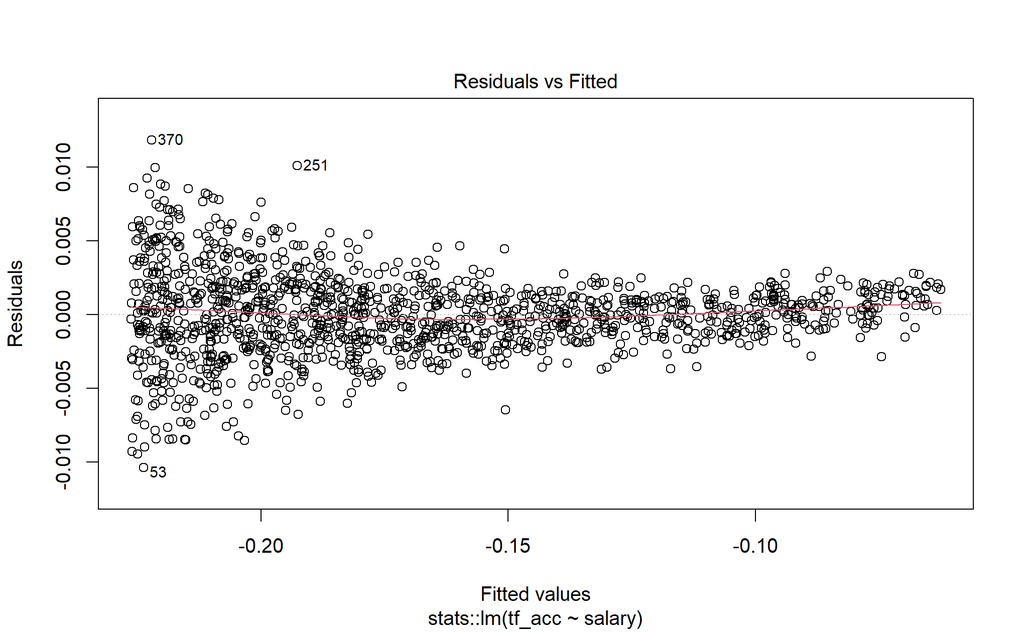

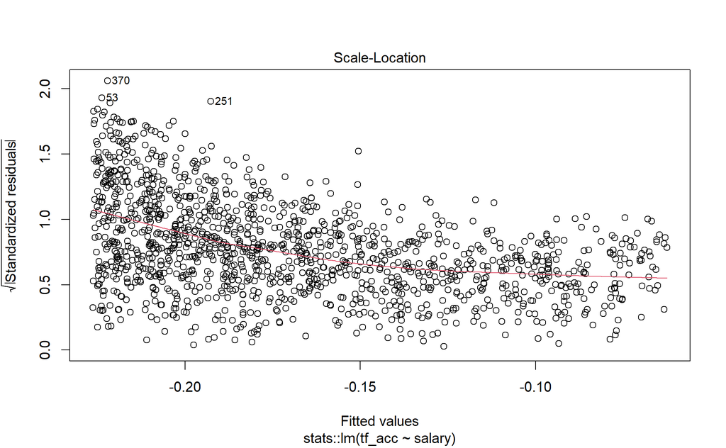

The Q-Q plot tracks the reference line near the centre but departs at both tails. Normality is imperfect across the full residual range. Independence is also uncertain, since the same player can appear across multiple seasons under different identifiers. No persistent identifier is available to test this directly.

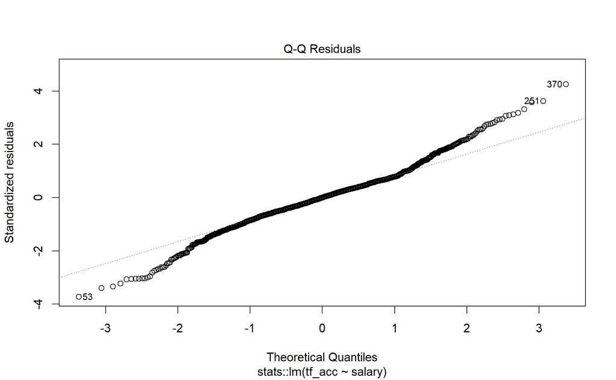

# 12. Salary Scenario Predictions

Point predictions, 97% prediction intervals and 97% confidence intervals are generated across thirteen illustrative salaries, from AUD 120,000 to AUD 480,000.

The chart below shows predicted accuracy across the full salary range. The wider band is the 97% prediction interval. The narrower band is the 97% confidence interval for the mean. The dashed line marks the 100% accuracy ceiling, a boundary the outcome can never physically cross.

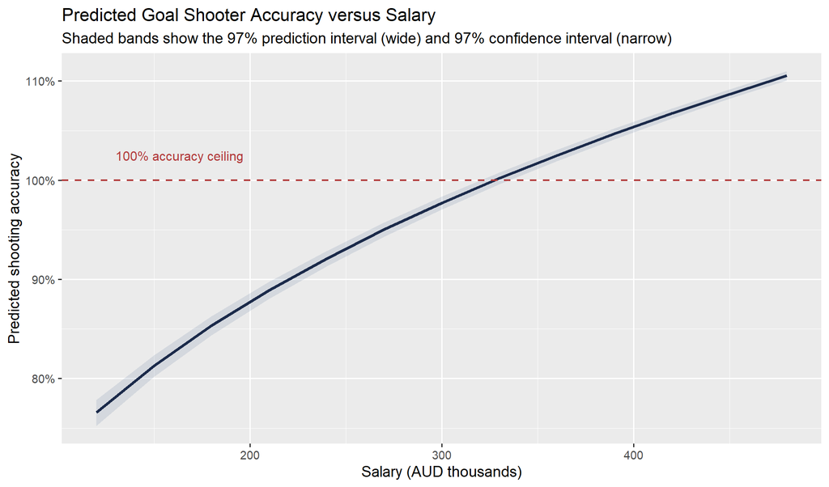

Predicted accuracy at the two salary points discussed in this report

| Salary (AUD thousands) | Predicted accuracy | 97% prediction interval | 97% confidence interval |
| --- | --- | --- | --- |
| 300 | 97.7% | 97.0% to 98.3% | 97.6% to 97.8% |
| 330 | 100.2% | 99.6% to 100.8% | 100.1% to 100.2% |

# 13 Management interpretation

# 14. Conclusion

Based on the analysis of the netball player dataset, specially focusing on Goal Shooters (GS), several key findings have identified. The analysis shows a strong positive relationship between a Goal Shooter’s salary and their performance metrics.Also, shooting accuracy and audience crowd has a strong positive relation. Specifically, higher salaries tend to correlate with better shooting accuracy and increased average crowd. Thus it indicates that higher-paid players not only perform better but also attract more spectators. These insights suggest that investing in top-performing, higher-salaried Goal Shooters could yield both performance and financial returns.

This is a specification limitation, not a flaw in the underlying relationship. The salary coefficient remains statistically significant, and the model still explains most of the variance in the sample. The boundary breach shows only that a straight-line model is unreliable near the upper limit of a bounded outcome.

# 15. Recommendations

- Use the model to compare scenarios and screen recruits, not to set a final contract figure.
- Do not treat AUD 330,000 as a recommended salary.
- Collect crowd-linked revenue and cost data before approving any salary above AUD 120,000.
- Treat predictions near 100% as a sign the model has reached its practical limit.

# 16. Risks and Limitations

- The data is observational. Reported relationships do not establish causation.
- The same player may appear across seasons under different identifiers, weakening the independence assumption.
- Linear-model assumptions are not fully satisfied.

# 17. Technical Appendix

## 17.1 Variable definitions

- `uni`: de-identified player identifier.
- `Height`: player height, in metres.
- `experience`: playing experience, in years.
- `salary`: salary, in AUD thousands.
- `position`: playing position.
- `goals`: successful goal attempts.
- `misses`: missed goal attempts.
- `avg_crowd`: average match crowd.
- `age_y`: derived player age, in years.
- `accuracy`: goals divided by total attempts.
- `tf_att`: Box-Cox transformed crowd.
- `tf_acc`: Box-Cox transformed shooting accuracy.

## 17.2 References

1. [`dplyr::arrange()` reference](https://dplyr.tidyverse.org/reference/arrange.html)
2. [`ggplot2::facet_wrap()` reference](https://ggplot2.tidyverse.org/reference/facet_wrap.html)
3. [`caret::BoxCoxTrans()` reference](https://topepo.github.io/caret/pre-processing.html#transformations-for-individual-predictors)

## 17.3 Reproducibility

This report uses relative file paths and fixed random seeds throughout, so the cleaning, sampling and modelling steps can be reproduced exactly. `tidyverse` handles import, cleaning and visualisation. `moments` calculates skewness. `caret` provides the Box-Cox transformation. `tidymodels` fits the linear model and generates predictions.